# Project Foundations for Data Science: FoodHub Data Analysis

### **Observation:**

### American cusine get highest number of orders ( ~584 order).

### Vietnamese cuisine gets least number of order( < 10 orders)

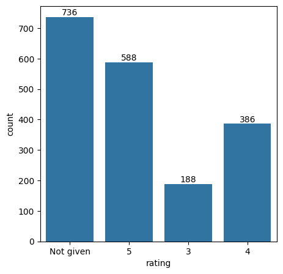

| rating | proportion |
| --- | --- |
| Not given | 0.39 |
| 5 | 0.31 |
| 4 | 0.20 |
| 3 | 0.10 |

**dtype:** float64

```python
plt.figure(figsize=(5,5))
ax2 = sns.countplot(x='rating',data=df)
for p in ax2.patches:
    ax2.annotate(f'{int(p.get_height())}',
                (p.get_x() + p.get_width() / 2., p.get_height()),
                ha='center', va='center', xytext=(0, 5), textcoords='offset points')
plt.show()
df['rating'].value_counts('normalize')
```

### **Observation:**

### 39% of the orders do not receive a rating

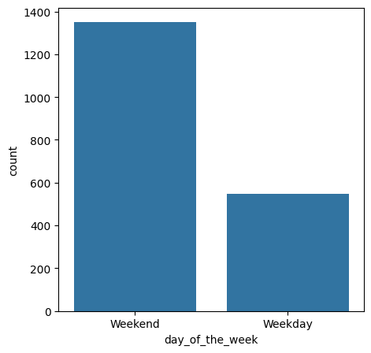

| day_of_the_week | proportion |
| --- | --- |
| Weekend | 0.71 |
| Weekday | 0.29 |

**dtype:** float64

```python
plt.figure(figsize=(5,5))
sns.countplot(x='day_of_the_week',data=df)

plt.show()
df['day_of_the_week'].value_counts('normalize')
```

### **Observation:**

71% of the orders are received of Weekends.

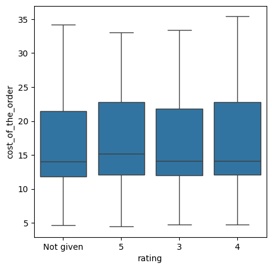

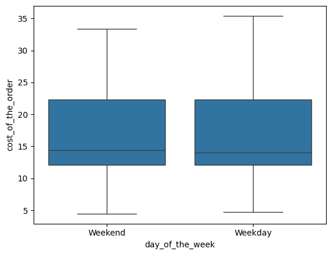

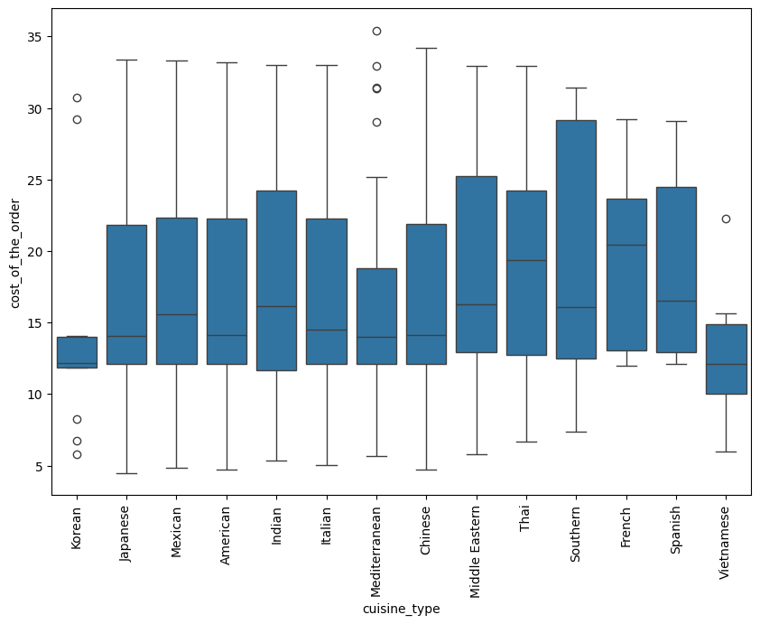

```python
plt.figure(figsize=(5,5))
sns.boxplot(x='rating',y='cost_of_the_order',data=df)

plt.show()
sns.boxplot(x='day_of_the_week',y='cost_of_the_order',data=df)
plt.show()
plt.figure(figsize=(10,7))
sns.boxplot(x='cuisine_type',y='cost_of_the_order',data=df)
plt.xticks(rotation=90)
plt.show()
```

### **Observation:**

- Cost of the order does not show much variance by rating and day of the week.Order with rating 5 have slightly higher median cost as compared to other ratings
- Thai and French Cuisines have higher median cost.
- Southern Cusine has higher interquartile range whereas Korean cuisines has smallest interquartile range

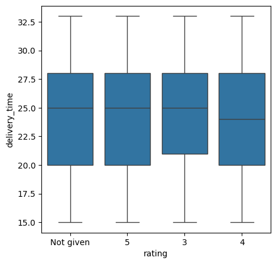

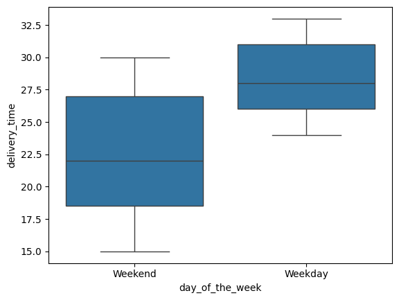

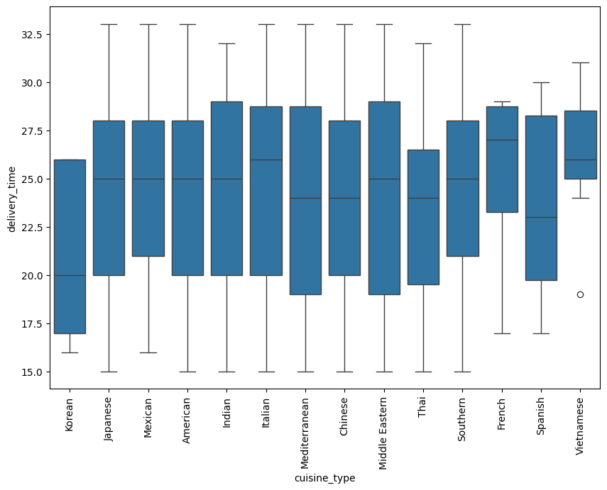

```python
plt.figure(figsize=(5,5))

sns.boxplot(x='rating',y='delivery_time',data=df)

plt.show()
sns.boxplot(x='day_of_the_week',y='delivery_time',data=df)
plt.show()


plt.figure(figsize=(10,7))
sns.boxplot(x='cuisine_type',y='delivery_time',data=df)
plt.xticks(rotation=90)

plt.show()
```

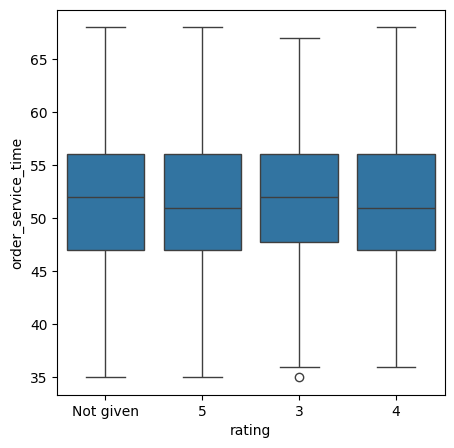

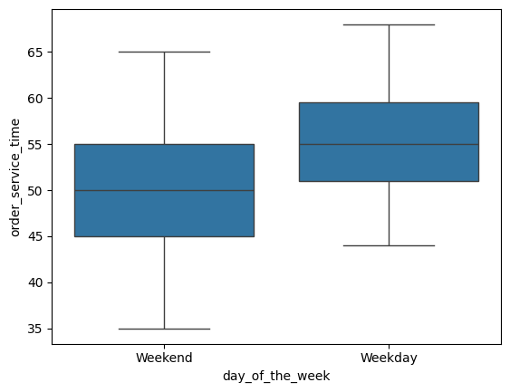

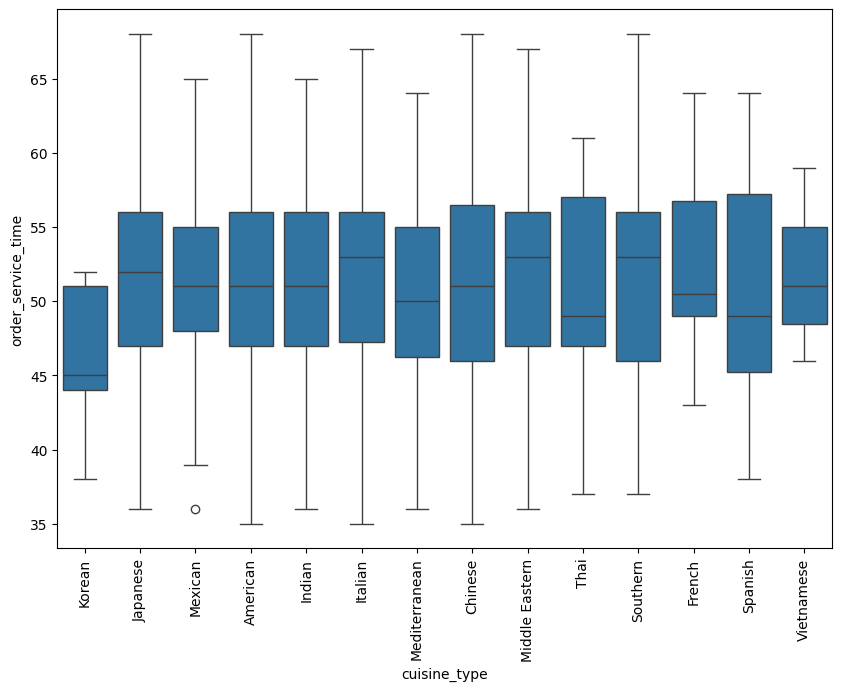

```python
plt.figure(figsize=(5,5))

sns.boxplot(x='rating',y='order_service_time',data=df)

plt.show()
sns.boxplot(x='day_of_the_week',y='order_service_time',data=df)
plt.show()


plt.figure(figsize=(10,7))
sns.boxplot(x='cuisine_type',y='order_service_time',data=df)
plt.xticks(rotation=90)

plt.show()
```

### **Observation:**

- Total delivery time(or order service) does not show much variation by rating.
- Orders take longer time to be completed on a Weekdays. Median delivery time for Weekday orders is 55 mins. vs 50 min for those on Weekends
- Spanish Cuisine has highest interquartile range for total delivery time where Vietnamese and Mexican cuisine has lowest interquartile range for this metric

### **Question 7**: Which are the top 5 restaurants in terms of the number of orders received? [1 mark]

```python
print('The top 5 restaurants by  number of orders received are ')
df.groupby('restaurant_name')['order_id'].count().sort_values(ascending=False).head(5 )
```

```
The top 5 restaurants by  number of orders received are
```

| restaurant_name | order_id |
| --- | --- |
| Shake Shack | 219 |
| The Meatball Shop | 132 |
| Blue Ribbon Sushi | 119 |
| Blue Ribbon Fried Chicken | 96 |
| Parm | 68 |

**dtype:** int64

### **Question 8**: Which is the most popular cuisine on weekends? [1 mark]

```python
t1 = df.groupby(['cuisine_type'])['day_of_the_week'].value_counts()
t1.loc[:,['Weekend']].sort_values(ascending=False).head(1)
```

| cuisine_type | day_of_the_week | count |
| --- | --- | --- |
| American | Weekend | 415 |

**dtype:** int64

# **Observations:**

American cuisine is the most popular cuisine on weekends

### **Question 9**: What percentage of the orders cost more than 20 dollars? [2 marks]

```python
print(f"{df[df['cost_of_the_order']>20].shape[0]/df.shape[0]*100:0.2f}% of the orders cost more than 20 dollars")
```

```
29.24% of the orders cost more than 20 dollars
```

# **Observations**:

29.2% order cost more than 20 dollars

### **Question 10**: What is the mean order delivery time? [1 mark]

```python
print(f"Average order delivery is {df['delivery_time'].mean().item():0.2f} minutes")
```

```
Average order delivery is 24.16 minutes
```

# **Observations**:

Average delivery time is 24 minutes

### **Question 11:** The company has decided to give 20% discount vouchers to the top 3 most frequent customers. Find the IDs of these customers and the number of orders they placed. [1 mark]

```python
print(f"Top 3 customer eligible for 20% discounts vouchers are:")
df['customer_id'].value_counts().head(3)
```

```
Top 3 customer eligible for 20% discounts vouchers are:
```

| customer_id | count |
| --- | --- |
| 52832 | 13 |
| 47440 | 10 |
| 83287 | 9 |

**dtype:** int64

### **Question 12**: Perform a multivariate analysis to explore relationships between the important variables in the dataset. (It is a good idea to explore relations between numerical variables as well as relations between numerical and categorical variables) [10 marks]

```python
#Average number of order per customer id
print( f"Avg # of orders by customer: {df.groupby(['customer_id'])['order_id'].nunique().mean():.2f}" )
#Average number of order per restaurant
print( f"Avg # of orders by restaurant:{df.groupby(['restaurant_name'])['order_id'].nunique().mean():.2f}")

print( f"Avg # of orders by rating :{ df.groupby(['rating'])['order_id'].nunique().mean():.2f}")
print( f"Avg # of orders by Cusine Type :{ df.groupby(['cuisine_type'])['order_id'].nunique().mean():.2f}")
```

```
Avg # of orders by customer: 1.58
Avg # of orders by restaurant:10.66
Avg # of orders by rating :474.50
Avg # of orders by Cusine Type :135.57
```

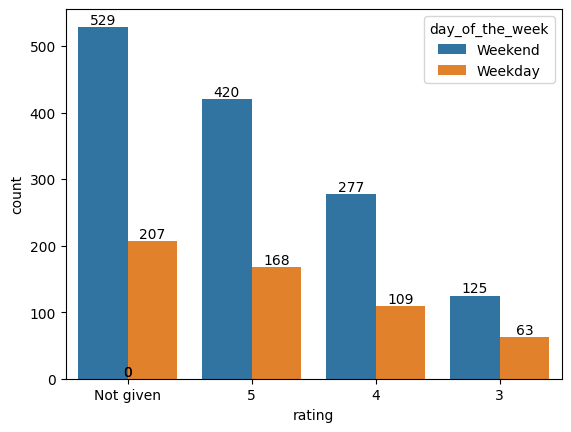

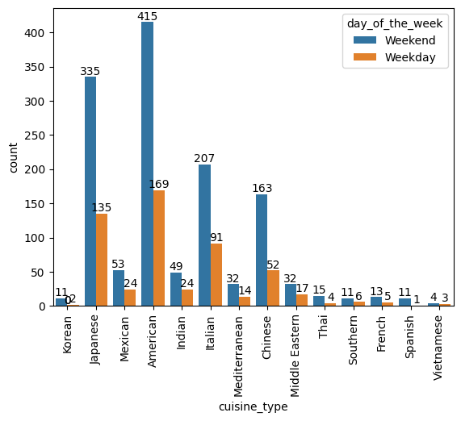

```python
# Bar chart by Ratinga and Day of the week
order_desc = df['rating'].value_counts().index

mv1 = sns.countplot(x='rating', data=df, hue='day_of_the_week',order=order_desc)
for p in mv1.patches:
    mv1.annotate(f'{int(p.get_height())}',
                (p.get_x() + p.get_width() / 2., p.get_height()),
                ha='center', va='center', xytext=(0, 5), textcoords='offset points')
plt.show()
# Bar chart by Cuisine Type and Day of the week
mv2 =sns.countplot(x='cuisine_type', data=df, hue='day_of_the_week')
for p in mv2.patches:
    mv2.annotate(f'{int(p.get_height())}',
                (p.get_x() + p.get_width() / 2., p.get_height()),
                ha='center', va='center', xytext=(0, 5), textcoords='offset points')
plt.xticks(rotation=90)
plt.show()
```

```python
# Summarize data by rating, day of the week to get average order cost and delivery times . Identify ratings and day of week that have highest cost and longest delivery time

pv_ost_ratin_dow =pd.pivot_table(df[['rating','day_of_the_week','cost_of_the_order','delivery_time','order_service_time']], index=['rating'],columns='day_of_the_week',aggfunc='mean' )
style_pv_ost_ratin_dow= pv_ost_ratin_dow.style.highlight_max(axis=0, props='background-color: lightblue;')
style_pv_ost_ratin_dow
```

| day_of_the_week rating | cost_of_the_order Weekday | cost_of_the_order Weekend | delivery_time Weekday | delivery_time Weekend | order_service_time Weekday | order_service_time Weekend |
| --- | --- | --- | --- | --- | --- | --- |
| 3 | 16.275397 | 16.197120 | 27.603175 | 23.024000 | 54.666667 | 50.640000 |
| 4 | 15.987982 | 16.994585 | 28.155963 | 22.180505 | 55.422018 | 49.628159 |
| 5 | 16.306667 | 17.229310 | 28.666667 | 22.430952 | 56.000000 | 49.795238 |
| Not given | 16.495942 | 15.924669 | 28.396135 | 22.521739 | 55.526570 | 49.967864 |

```python
# Summarize data by cusines, day of the week to get average order cost and delivery times . Identify cusines and day of week that have highest cost and longest delivery time
pivot_tab_order_service_time = pd.pivot_table(df[['cuisine_type','day_of_the_week','cost_of_the_order','delivery_time','order_service_time']], index=['cuisine_type'],columns='day_of_the_week',aggfunc='mean' )
style_pv_ost= pivot_tab_order_service_time .style.highlight_max(axis=0, props='background-color: lightblue;')
style_pv_ost
```

| day_of_the_week cuisine_type | cost_of_the_order Weekday | cost_of_the_order Weekend | delivery_time Weekday | delivery_time Weekend | order_service_time Weekday | order_service_time Weekend |
| --- | --- | --- | --- | --- | --- | --- |
| American | 15.308343 | 16.731735 | 28.248521 | 22.542169 | 55.656805 | 49.995181 |
| Chinese | 17.147692 | 16.036442 | 28.826923 | 22.269939 | 56.903846 | 49.601227 |
| French | 20.866000 | 19.381538 | 27.200000 | 24.615385 | 54.400000 | 51.384615 |
| Indian | 17.162500 | 16.800816 | 27.625000 | 22.346939 | 53.958333 | 49.836735 |
| Italian | 16.890110 | 16.211449 | 28.802198 | 22.705314 | 56.219780 | 50.217391 |
| Japanese | 16.368074 | 16.278925 | 28.133333 | 22.519403 | 55.414815 | 50.122388 |
| Korean | 12.180000 | 14.332727 | 26.000000 | 20.000000 | 49.000000 | 45.909091 |
| Mediterranean | 14.040000 | 16.102500 | 28.785714 | 21.312500 | 54.571429 | 48.843750 |
| Mexican | 16.555833 | 17.103962 | 28.250000 | 22.641509 | 53.875000 | 49.867925 |
| Middle Eastern | 19.832941 | 18.282812 | 28.470588 | 21.750000 | 55.705882 | 48.125000 |
| Southern | 19.226667 | 19.340909 | 29.500000 | 20.727273 | 55.666667 | 49.090909 |
| Spanish | 12.130000 | 19.618182 | 28.000000 | 23.000000 | 61.000000 | 49.363636 |
| Thai | 15.462500 | 20.206667 | 26.500000 | 22.266667 | 51.750000 | 50.133333 |
| Vietnamese | 11.916667 | 13.607500 | 27.666667 | 25.000000 | 51.333333 | 52.250000 |

### **Question 13:** The company wants to provide a promotional offer in the advertisement of the restaurants. The condition to get the offer is that the restaurants must have a rating count of more than 50 and the average rating should be greater than 4. Find the restaurants fulfilling the criteria to get the promotional offer. [3 marks]

```python
df['rating_count'] = df.groupby('restaurant_name')['rating'].transform('count')
df['rating_numeric'] = df['rating'].apply(lambda x: float(x) if x != 'Not given' else np.nan)
df['avg_rating'] = df.groupby('restaurant_name')['rating_numeric'].transform('mean')
df.head()
print('Restaurants with rating count more than 50 and 4+ average rating are ',(df[(df['rating_count']>50) & (df['avg_rating']>4)]['restaurant_name'].unique()[1:]))
```

```
Restaurants with rating count more than 50 and 4+ average rating are  ['The Meatball Shop' 'Shake Shack' 'RedFarm Hudson' 'Blue Ribbon Sushi'
 'Parm' 'RedFarm Broadway']
```

#### Observations:

### **Question 14:** The company charges the restaurant 25% on the orders having cost greater than 20 dollars and 15% on the orders having cost greater than 5 dollars. Find the net revenue generated by the company across all orders. [3 marks]

```python
def revenue(x):
  if x>20:
    return x*.25
  elif x>5:
    return x*.15
  else:
    return 0
df['revenue'] = df['cost_of_the_order'].apply(revenue)
df.head()
print(f"Net Revenue generated by the company across all 3 orders $ {df.revenue.sum():0.2f}")
```

```
Net Revenue generated by the company across all 3 orders $ 6166.30
```